# Replication of Cheynel and Liu-Watts (2020)

Shunsuke Matsuno

2020/7/28

# Description

- “A Simple Structural estimator of Disclosure Costs” by Cheynel and Liu-Watts, 2020, RAST.
- In this note we replicate Section 2.5 of the original paper.
- In addition, we check the behavior of the proposed estimator with several underlying distributions of firm values.
- All the original functions can be found [here](https://github.com/ShunsukeMatsuno/DisclosureCost).

# Required libraries

```r
easypackages::libraries('tidyverse', 'ggplot2', 'patchwork', 'CheynelLiuWatts')
```

# Simulation

- There are $N=10,000$ firms and each firm has $T=40$ periods.
- Private signal $x$ is drawn from standard normal distribution.
  - Note that $x$ is actually the manager’s posterior expectation about future earnings. However, we can effectively regard that manager observes random $x$ and investors form belief about $x$.
- We generate $N$ firms for each possible cost $c$, where $c \in \{ 0.4, 0.5, \dots, 2.1 \}$.

```r
# seed
set.seed(2020)

# simulation settings
num_firms <- 10000                   # 10,000 firms for each cost
periods   <- 40                      # 40 periods for each firm
c_vec     <- seq(0.4, 2.1, by = .1)  # grid of cost
```

## Simulating true cost and disclosure

- Each firm has 40 periods.
- `x` is the private information about firm value, which is iid across firms and over time.
- The cost of disclosure $c$ is assumed to vary across firms but constant over period in each firm.

```r
# firm
df_firm <- tibble(
  firm = rep(1:(num_firms * length(c_vec)), each = periods),
  time = rep(1:periods, times = num_firms * length(c_vec)),
  x    = rnorm(num_firms * length(c_vec) * periods),
  c    = rep(c_vec, each = num_firms * periods)
)
df_firm
```

```
# A tibble: 7,200,000 x 4
    firm  time      x     c
   <int> <int>  <dbl> <dbl>
 1     1     1  0.377   0.4
 2     1     2  0.302   0.4
 3     1     3 -1.10    0.4
 4     1     4 -1.13    0.4
 5     1     5 -2.80    0.4
 6     1     6  0.721   0.4
 7     1     7  0.939   0.4
 8     1     8 -0.229   0.4
 9     1     9  1.76    0.4
10     1    10  0.117   0.4
# ... with 7,199,990 more rows
```

- The threshold is determined by
  $$\tau - c = \mathbb{E}[x \mid x \le \tau].$$
- To solve this equation, we write a function that computes $\mathbb{E}[x \mid x \le \tau] - (\tau - c )$, and minimize it.
- `compute_threshold.R` do this computation.
  - The following code takes a couple of minutes.

```r
compute_threshold
```

```
function(x, c){
  # x and c are private signals and cost of disclosure for each firm.
  # x and cis T-dimensional vector, where T is the observed number of periods of the firm.

  c <- unique(c)

  obj <- function(tau){
    if(is.na(mean(x[x <= tau]))){
      m <- 0
    }else{
      m <- mean(x[x <= tau])
    }
    return(abs(m - (tau - c)))
  }

  opt_res <- optim(par = .3,
                   fn = obj,
                   method = 'Brent',
                   lower = min(x) - 1,
                   upper = max(x) + 1)

  return(opt_res$par)

}
<bytecode: 0x000000002568ad08>
<environment: namespace:CheynelLiuWatts>
```

```r
df_tau <- df_firm %>%
  group_by(firm) %>%
  summarise(tau = compute_threshold(x, c),
            .groups = "drop")
df_firm <- left_join(df_firm, df_tau, by = "firm")
```

- If $x>=\tau$, then firm’s disclose their $x$, and if not, they do not disclose.

```r
df_firm <- df_firm %>%
  mutate(disclosure = if_else(x >= tau, x, NA_real_))
df_firm
```

```
# A tibble: 7,200,000 x 6
    firm  time      x     c   tau disclosure
   <int> <int>  <dbl> <dbl> <dbl>      <dbl>
 1     1     1  0.377   0.4 0.117      0.377
 2     1     2  0.302   0.4 0.117      0.302
 3     1     3 -1.10    0.4 0.117     NA
 4     1     4 -1.13    0.4 0.117     NA
 5     1     5 -2.80    0.4 0.117     NA
 6     1     6  0.721   0.4 0.117      0.721
 7     1     7  0.939   0.4 0.117      0.939
 8     1     8 -0.229   0.4 0.117     NA
 9     1     9  1.76    0.4 0.117      1.76
10     1    10  0.117   0.4 0.117     NA
# ... with 7,199,990 more rows
```

- Finally, for the purpose of estimation, each firm must have at least one period of disclosure and one period of non-disclosure.
  - Firms that do not satisfy this criterion ( (not) disclosing in all periods) are dropped from sample.

```r
df_firm <- df_firm %>%
  group_by(firm) %>%
  mutate(remain_firm =
           if_else(
             sum(!is.na(disclosure)) == 0 | sum(is.na(disclosure)) == 0,
             FALSE,
             TRUE)) %>%
  ungroup() %>%
  filter(remain_firm) %>%
  select(-remain_firm)     # this variable is no longer needed
```

## Estimation

- Using the simulated data, we estimate the cost of disclosure by the following procedure:
1. Estimate $p$, $\tau$, $m := \mathbb{E}[x\mid x>\tau]$.
   - $\hat{p} = \text{sample disclosure frequency}$
   - $\hat{\tau} = \min\{\text{observed } x\}$
   - $\hat{m} = \text{average forecast surprise}$
2. Estiate $c$ by
   $$\begin{align*}
   \hat{c}_{\textit{NP}} & =\max\left(0,\hat{\tau}+\frac{\hat{p}}{1-\hat{p}}\hat{m}\right),\\
   \hat{c}_{\textit{BBT}} & =\Phi^{-1}(1-\hat{p})+\frac{\phi\left(\Phi^{-1}(1-\hat{p})\right)}{1-\hat{p}}.
   \end{align*}$$
- `estimate_c_NP.R` and `estimate_c_BBT.R` do this procedure.

```r
estimate_c_NP
```

```
function(df){
  df_cost <- df %>%
    group_by(firm) %>%
    mutate(p_hat = mean(!is.na(disclosure)),
           tau_hat = min(disclosure, na.rm = TRUE),
           m_hat = mean(disclosure, na.rm = TRUE)) %>%
    mutate(c_NP = max(0, tau_hat + p_hat/(1 - p_hat) * m_hat))

  c_NP <- df_cost %>% pull(c_NP)

  return(c_NP)
}
<bytecode: 0x000000000769d878>
<environment: namespace:CheynelLiuWatts>
```

```r
estimate_c_BBT
```

```
function(df){
  df_cost <- df %>%
    group_by(firm) %>%
    mutate(p_hat = mean(!is.na(disclosure))) %>%
    mutate(c_BBT = qnorm(1 - p_hat) + dnorm(qnorm(1 - p_hat)) / (1 - p_hat))

  c_BBT <- df_cost %>% pull(c_BBT)

  return(c_BBT)
}
<bytecode: 0x00000000078813d0>
<environment: namespace:CheynelLiuWatts>
```

- Since there is no within-variaion in true and estimated cost, we collapse the data.

```r
df_cost <- df_firm %>%
  mutate(c_NP  = estimate_c_NP(.),
         c_BBT = estimate_c_BBT(.)) %>%
  group_by(firm) %>%
  summarise(across(starts_with("c"), .fns = first),
            .groups = "drop")
```

- Since we know the true cost, we can compute bias and absolute error.

```r
df_cost <- df_cost %>%
  group_by(c) %>%
  summarise(bias_NP   = mean(c_NP - c, na.rm = TRUE),
            bias_BBT  = mean(c_BBT - c, na.rm = TRUE),
            error_NP  = mean(abs(c_NP - c), na.rm = TRUE),
            error_BBT = mean(abs(c_BBT - c), na.rm = TRUE),
            .groups   = "drop")
df_cost
```

```
# A tibble: 18 x 5
       c bias_NP  bias_BBT error_NP error_BBT
   <dbl>   <dbl>     <dbl>    <dbl>     <dbl>
 1   0.4   0.751  0.103       1.05     0.109
 2   0.5   0.595  0.0469      0.931    0.0964
 3   0.6   0.404 -0.00947     0.767    0.103
 4   0.7   0.313 -0.0493      0.665    0.132
 5   0.8   0.233 -0.0611      0.538    0.157
 6   0.9   0.118 -0.0363      0.351    0.157
 7   1     0.104 -0.0182      0.283    0.158
 8   1.1   0.106 -0.00700     0.249    0.166
 9   1.2   0.123 -0.00580     0.257    0.180
10   1.3   0.148 -0.00926     0.273    0.200
11   1.4   0.176  0.000836    0.289    0.213
12   1.5   0.210 -0.00620     0.315    0.227
13   1.6   0.215 -0.0209      0.319    0.225
14   1.7   0.264 -0.0467      0.369    0.240
15   1.8   0.279 -0.0791      0.381    0.236
16   1.9   0.291 -0.134       0.398    0.241
17   2     0.303 -0.201       0.428    0.222
18   2.1   0.290 -0.281       0.444    0.281
```

- Plot bias and error (Fig.1 of original paper).

[figure not shown]

```r
# bias
df_cost_plot_bias <- df_cost %>%
  group_by(c) %>%
  summarise(across(bias_NP:bias_BBT, mean),
            .groups = "drop") %>%
  pivot_longer(-c, names_to = 'type', values_to = 'bias')

g1 <- ggplot(df_cost_plot_bias, aes(x = c, y = bias, color = type)) +
  geom_line(aes(linetype = type), size = 1) +
  theme_bw() +
  theme(legend.position = 'top')

# error
df_cost_plot_error <- df_cost %>%
  group_by(c) %>%
  summarise(across(error_NP:error_BBT, mean),
            .groups = "drop") %>%
  pivot_longer(-c, names_to = 'type', values_to = 'error')

g2 <- ggplot(df_cost_plot_error, aes(x = c, y = error, color = type)) +
  geom_line(aes(linetype = type), size = 1) +
  theme_bw() +
  theme(legend.position = 'top')

p <- g1 + g2 + plot_layout(ncol = 1)
plot(p)
```

```r
ggsave("cost_simulated.png", p, path = "../output/figure", width = 8, height = 5)
```

## Robustness to distrbtutional assumption

- What happens if $x$ is not distributed normally?
  - BBT estimator assumes that $x$ follows normal distribution.
  - NP estimator does not impose any distributional assumption on $x$.
- `bias_error_plot_distribution.R` plots bias and error with several distributional assumptions.
  - `dist = 1`: standard normal
  - `dist = 2`: uniform dist. over $[-3,3]$
  - `dist = 3`: exponential dist. with rate $1$
  - `dist = 4`: t-dist. with df $5$
- As shown in the following figures, NP estimator outperforms BBT estimator only in the case of uniform distribution when $c$ is high.
  - Overall, the BBT estimator is robust.
  - For example, the exponential distribution with rate $1$ is quite skewed compared to standard normal, while BBT estimator which assumes normality offers good estimates.
  - The poor result of the NP estimator might come from the small $T$.
    - $\hat{\tau}$ and $\hat{m}$ are poorly estimated with sample size of 40.

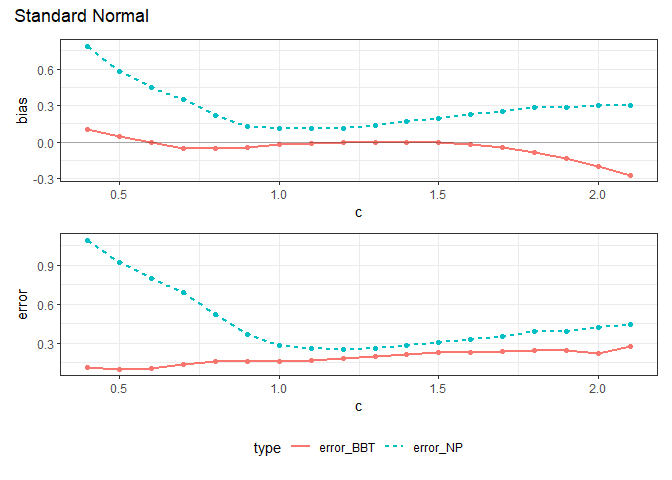

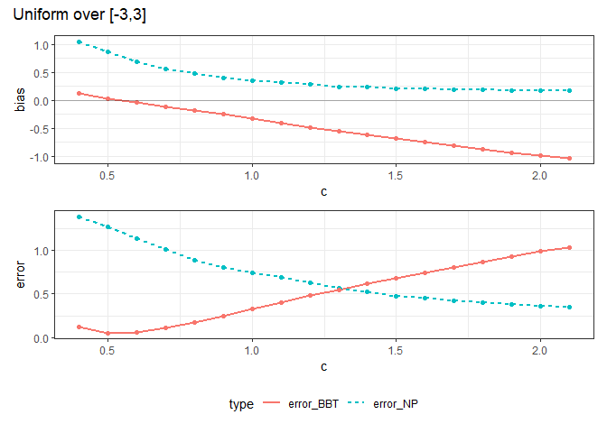

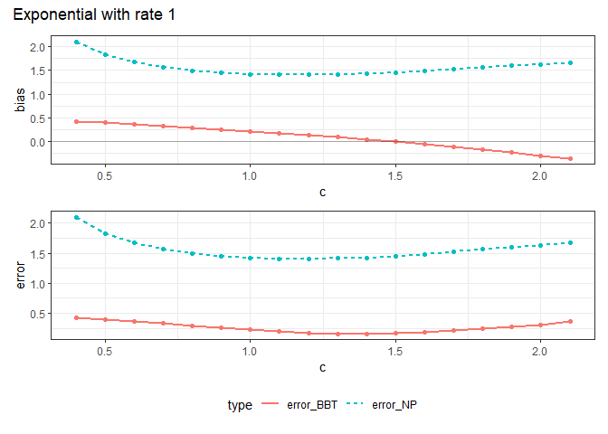

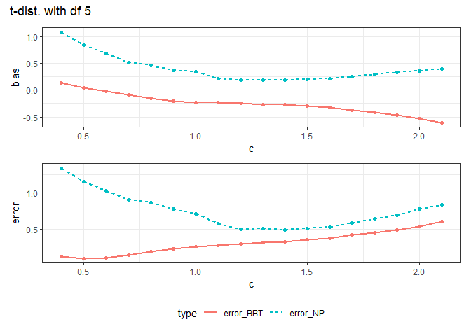

```r
library(doParallel)
cl <- makePSOCKcluster(parallel::detectCores(logical = FALSE))
doParallel::registerDoParallel(cl)

obj <- numeric(4)

obj <- foreach (i = 1:4,
        .packages = c('dplyr', 'ggplot2', 'patchwork', 'tidyr', 'CheynelLiuWatts')) %dopar% {
  obj[i] <- bias_error_plot_distribution(dist = i,
                                         num_firms = num_firms,
                                         periods = periods)
}

stopCluster(cl)

obj
```

- To see the importance of large $T$, let us take $T = 200$.
  - Since $T$ is quarterly scale, $T=200$ means $50$ years.
  - It is unusual to have data of $50$ years.

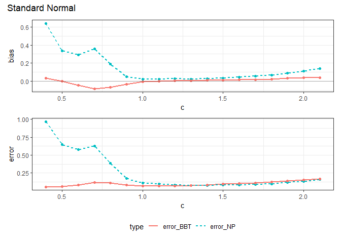

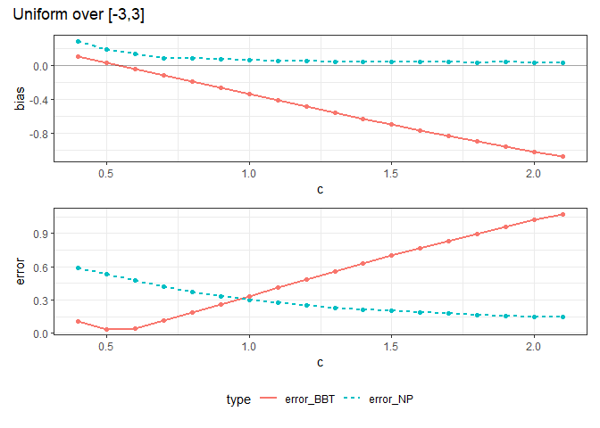

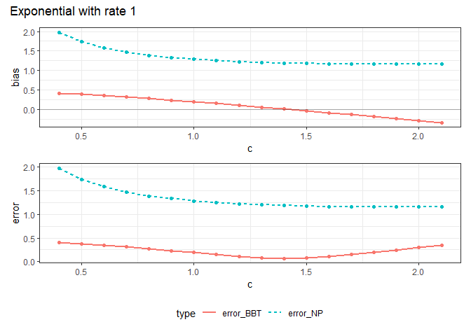

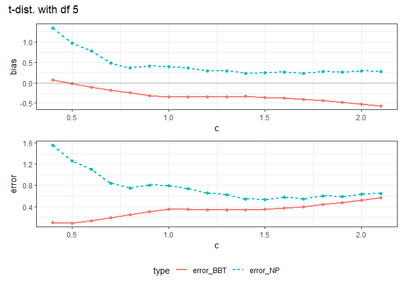

```r
cl <- makePSOCKcluster(parallel::detectCores(logical = FALSE))
doParallel::registerDoParallel(cl)

obj <- numeric(4)

obj <- foreach (i = 1:4,
        .packages = c('dplyr', 'ggplot2', 'patchwork', 'tidyr', 'CheynelLiuWatts')) %dopar% {
  obj[i] <- bias_error_plot_distribution(dist = i,
                                         num_firms = num_firms,
                                         periods = 200)
}

stopCluster(cl)

obj
```